# final exam

## 1. (25%)

Answer the following questions:

1. Give two simple functions to evaluate the sum of each column for a matrix. (Do not use for(. . . ))

Ans:colSums(),apply()

2. What is the function that can be used for comparion of computation time?

Ans:benchmark()

3. Try to use function in the family “APPLY” and the defined function to evaluate the following quantity for each row of a matrix?

```r
row.sum<-function(x){
  row<-c()
  n<-dim(x)[2]
  row_mean<-apply(x,1,mean)
  for (rr in row_mean){
    c=0
    for (cc in (1:n)){
      c<-c+((abs(cc-rr))/n)
    }
    row<-c(row,c)
  }
  return(row)
}
X <- matrix(c(-0.45 , 0.77, 0.16, 1.22, 1.75, 0.24,
0.27, 1.74, 0.07, -0.87, -0.90, 1.07,
-0.06, 0.33, -0.06, 0.09, 0.10, -0.04), 3, 6, byrow = TRUE)
row.sum(X)
```

```
## [1] 2.885 3.270 3.440
```

4. Draw the curve by the following equations and identify what the graph is.

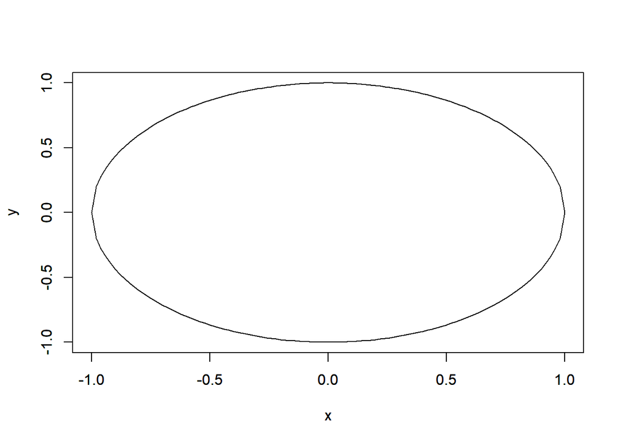

```r
curve((1-x^2)^(1/2),-1,1,ylim=c(-1,1),ylab="y")
par(new=TRUE)
curve(-((1-x^2)^(1/2)),-1,1,ylim=c(-1,1),ylab="y")
```

the graph is a circle. (e) Use the dataset iris. Write a code to draw the plot

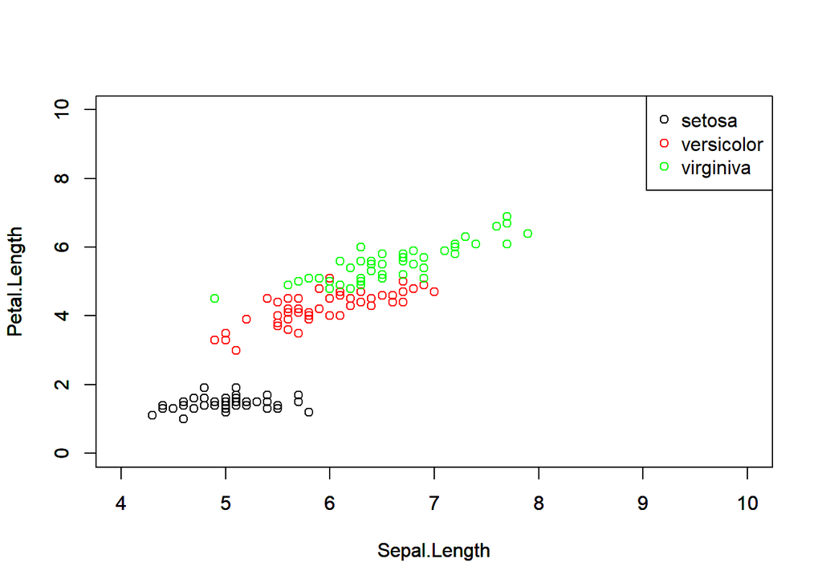

```r
data.le<-iris
s<-data.le[data.le[,"Species"]=="setosa",c("Sepal.Length","Petal.Length")]
plot(s$Sepal.Length,s$Petal.Length,xlim=c(4,10),ylim=c(0,10),xlab="Sepal.Length",ylab="Petal.Length")
par(new=TRUE)
v<-data.le[data.le[,"Species"]=="versicolor",c("Sepal.Length","Petal.Length")]
plot(v$Sepal.Length,v$Petal.Length,xlim=c(4,10),ylim=c(0,10),xlab="Sepal.Length",ylab="Petal.Length",col="red")
par(new=TRUE)
vir<-data.le[data.le[,"Species"]=="virginica",c("Sepal.Length","Petal.Length")]
plot(vir$Sepal.Length,vir$Petal.Length,xlim=c(4,10),ylim=c(0,10),xlab="Sepal.Length",ylab="Petal.Length",col="green")
legend("topright",c("setosa","versicolor","virginiva"),pch=1,col=c("black","red","green"))
```

## 2. (30%)

Download the package “titanic” and library(“titanic”). Use data(titanic_train) to the following questions:

```r
library("titanic")
data.2<-titanic_train
```

(a)Extract the column names of the dateset.

```r
people<-unique(data.2$Name)
pp<-length(people)
pp
```

```
## [1] 891
```

(b)How many people are there in the dataset? The column “Survived” is Passenger Survival Indicator with dead 0 and survival 1. How many survived people are there?

891 people.

```r
s<-data.2[data.2$Survived==1,"Sex"]
ss<-length(s)
ss
```

```
## [1] 342
```

3. Draw two pie charts for the columns of Survived and Sex

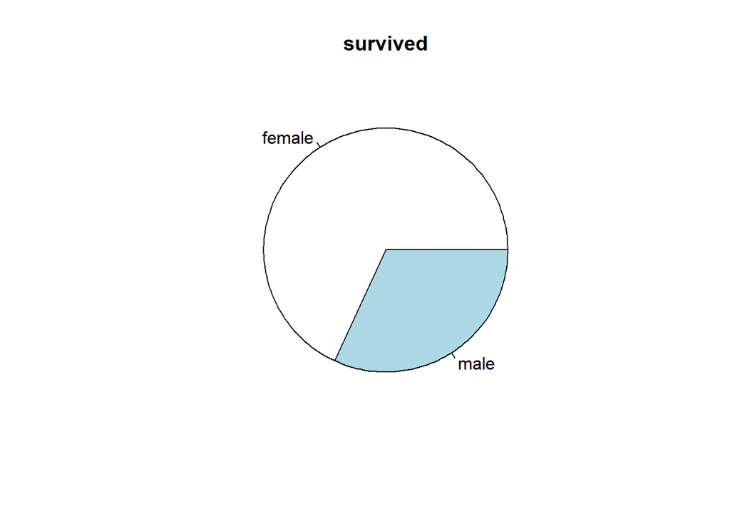

```r
pie(table(s),main="survived")
```

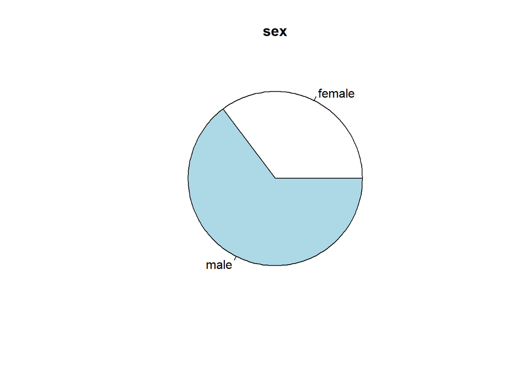

```r
pie(table(data.2$Sex),main="sex")
```

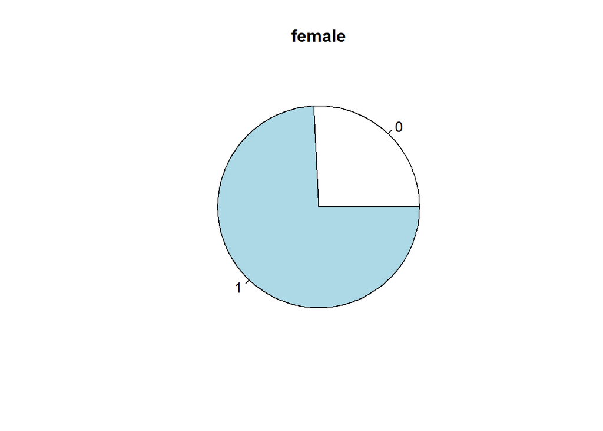

```r
sex_f<-data.2[data.2$Sex=="female","Survived"]
pie(table(sex_f),main="female")
```

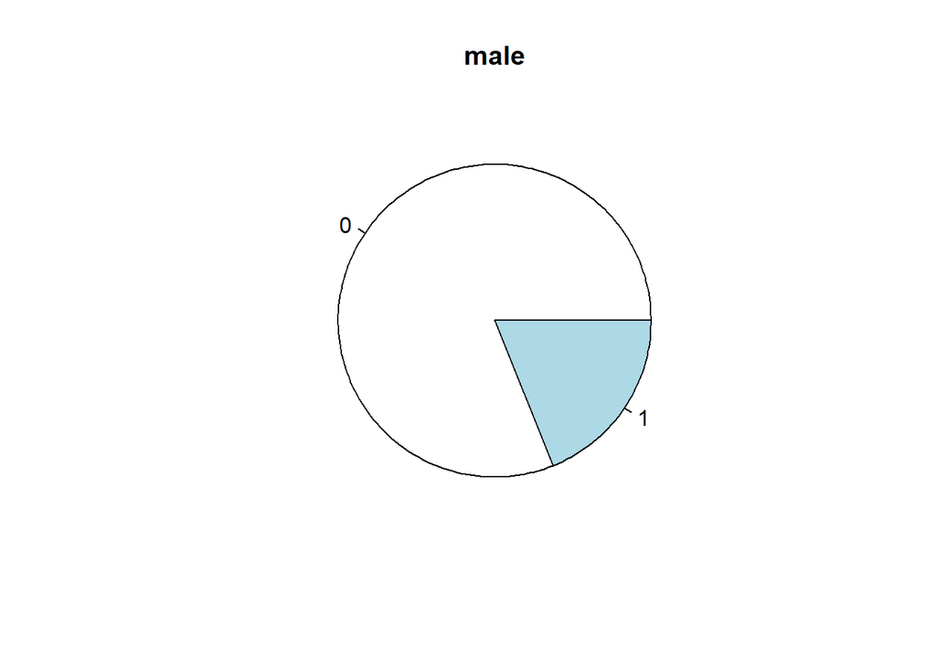

```r
sex_m<-data.2[data.2$Sex=="male","Survived"]
pie(table(sex_m),main="male")
```

(d)Provide the value of percentage of each gender in both survival group and dead group.

survival:38.4%

dead:61.6%

5. Try to write a code with function(…) to creat the dummy variables for an arbitrary discrete variable.

```r
dummy<-function(x){
  n<-unique(x)
  df<-data.frame(n)
  for (j in x){
    c<-c(rep(0,j-1),1,rep(0,length(n)-j))
    df<-rbind(df,c)
  }
  df<-df[-1,]
  return(df)
}
```

(f)Use titanic_train$Pclass and titanic_train$Sex to test your function in (e). Report the sum of each column of dummy variables.

```r
dummy(as.list(data.2$Pclass))
```

```
##     X3L X1L X2L
## 2     0   0   1
## 3     1   0   0
## 4     0   0   1
## 5     1   0   0
## 6     0   0   1
## 7     0   0   1
## 8     1   0   0
## 9     0   0   1
## 10    0   0   1
## 11    0   1   0
## 12    0   0   1
## 13    1   0   0
## 14    0   0   1
## 15    0   0   1
```

[output cut: 877 more lines]

```r
#dummy(as.list(data.2$Sex))
```

## 3. (15%)

Let x <- seq(-1.5, 1.5, 0.01) and y <- seq(-1.5, 1.5, 0.01). (a) • Use a matrix to collect all possible combinations of x and y into a matrix satisfying

```r
x<-seq(-1.5,1.5,0.01);y<-seq(-1.5,1.5,0.01)
m<-matrix(nrow=0,ncol=3)
for (xx in x){
  for (yy in y){
    k<-xx^2*yy^3-(xx^2+yy^2-1)^3
    if (k>=0){
     m<- rbind(m,c(xx,yy,k))
    }else{
      next
    }
  }
}
```

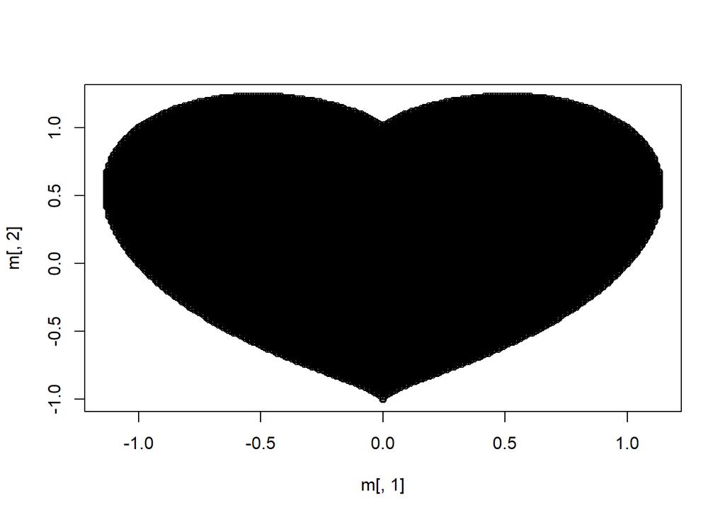

```r
plot(m[,1],m[,2])
```

is a love!!!!!!

## 4. (30%)

Download the package “nlme” and library(nlme). Begin with the data: data(Fatigue). There are three columns, which are “Path”, “cycles”, and “relLength”. Path means the ID number of a unit, cycles means the measurement time point, and relLength means the crack length over cycles. Use the Fatigue data to the following questions:

```r
library("nlme")
data.4<-Fatigue
```

(a)How many units are there in the dataset?

```r
p<-unique(data.4$Path)
length(p)
```

```
## [1] 21
```

(b)Try to plot the degradation path for all of the units, which means the x-axis is the cycles and the y-axis is the relLength. Note that there are n (from (a)) paths in the same plot, and use type = “b” in plot(…). (The label names of x-axis and y-axis should be meaningful.)

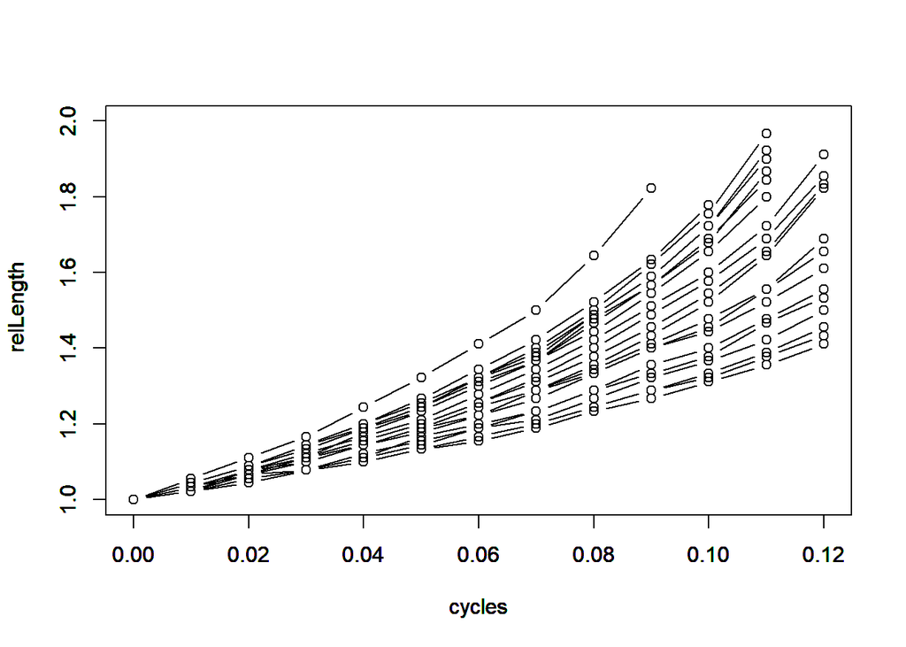

```r
for (i in (1:20)){
  a<-data.4[data.4$Path==i,c("cycles","relLength")]
  plot(a$cycle,a$relLength,type="b",xlab="cycles",ylab=" relLength",xlim=c(0,0.12),ylim=c(1,2))
  par(new=TRUE)
}
par(new=TRUE)
a<-data.4[data.4$Path==21,c("cycles","relLength")]
  plot(a$cycle,a$relLength,type="b",xlab="cycles",ylab=" relLength",xlim=c(0,0.12),ylim=c(1,2))
```

(c)Define the failure threshold to be 1.4. Add an horizontal line at 1.4 to the plot in (b) by different format (eg, different style of line or different color).

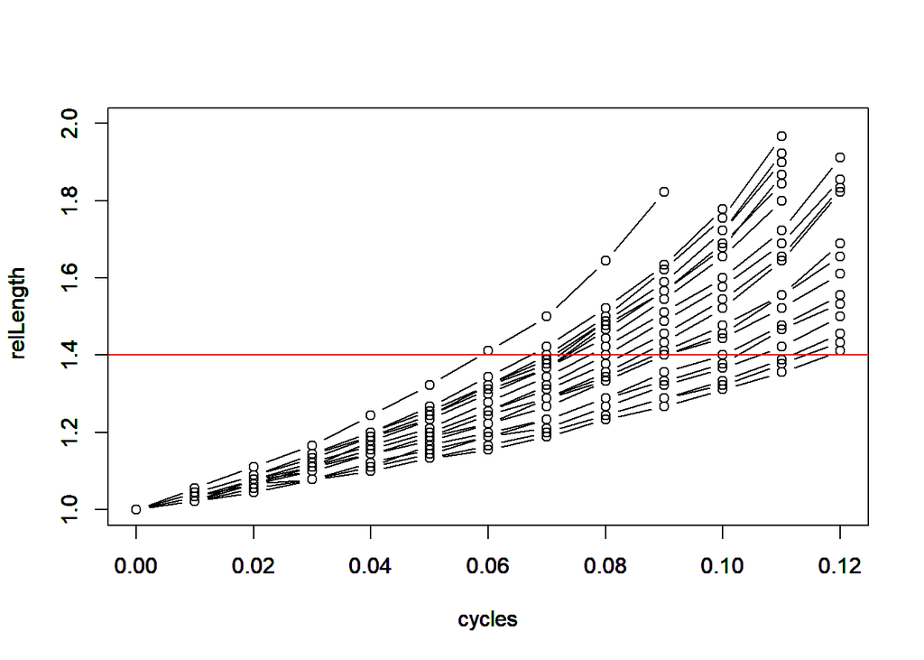

```r
for (i in (1:20)){
  a<-data.4[data.4$Path==i,c("cycles","relLength")]
  plot(a$cycle,a$relLength,type="b",xlab="cycles",ylab=" relLength",xlim=c(0,0.12),ylim=c(1,2))
  par(new=TRUE)
}
par(new=TRUE)
a<-data.4[data.4$Path==21,c("cycles","relLength")]
  plot(a$cycle,a$relLength,type="b",xlab="cycles",ylab=" relLength",xlim=c(0,0.12),ylim=c(1,2))
abline(h=1.4,lty=1,col="red")
```

(d) Try to provide the number of failures in the dataset during the testing period.

```r
f<-data.4[data.4$relLength>=1.4,"cycles"]
length(f)
```

```
## [1] 73
```

5. Use a transformation y = log(relLength), and fit a linear regression for each path with the following model:

```r
#y<-log(data.4$relLength)
#data.4$log<-y
#aa<-data.4[data.4$Path==1,c("cycles","log")]
#aa
#lm1<-lm(log~cycles-1,data=aa)
#summary(lm)
```